# Trabalho Final

# Questão 3:

Existe correlação entre o tempo de prisão e o score de periculosidade? Utilize um nível de significância de 5% e apresente o valor do coeficiente de correlação.

## 1. Visualização da normalidade para ‘tempo_preso’

```r
qq1 <- ggqqplot(dados$tempo_preso)
```

## 2. Visualização da normalidade para ‘score_periculosidade’

```r
qq2 <- ggqqplot(dados$score_periculosidade)
```

## 3. Exibição conjunta

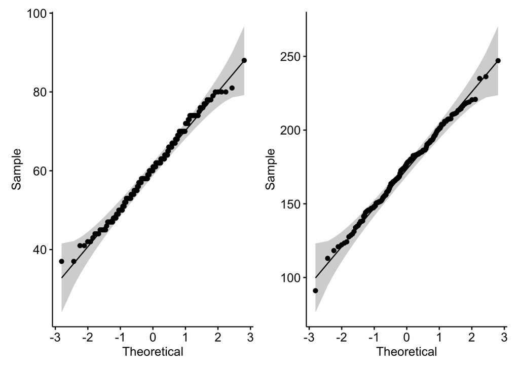

```r
qq1 + qq2
```

## 4. Teste formal de Shapiro-Wilk para ‘tempo_preso’

```r
shapiro.test(x = dados$tempo_preso)
```

```
##
##  Shapiro-Wilk normality test
##
## data:  dados$tempo_preso
## W = 0.99252, p-value = 0.4003
```

## 5. Teste formal de Shapiro-Wilk para ‘score_periculosidade’

```r
shapiro.test(x = dados$score_periculosidade)
```

```
##
##  Shapiro-Wilk normality test
##
## data:  dados$score_periculosidade
## W = 0.99516, p-value = 0.7738
```

## 6. Interpretação:

- Tempo de Prisão: O p-valor (0.4003) é maior que o nível de significância de 0.05. Portanto, não rejeitamos a Hipótese Nula ($H_0$).

> **Concluímos que não há evidência estatística de que a variável tempo_preso se afaste da normalidade.**
- Score de Periculosidade: O p-valor (0.7738) também é maior que 0.05. Não rejeitamos a $H_0$, indicando que é razoável assumir que o score_periculosidade possui distribuição aproximadamente normal.

> **Como ambas as variáveis se aproximam da distribuição normal, o teste de correlação de *Pearson* é o procedimento estatistico adequado.**

## 7. Definição do teste de correlação

### 7.1. Gráfico de dispersão para avaliar a relação visualmente

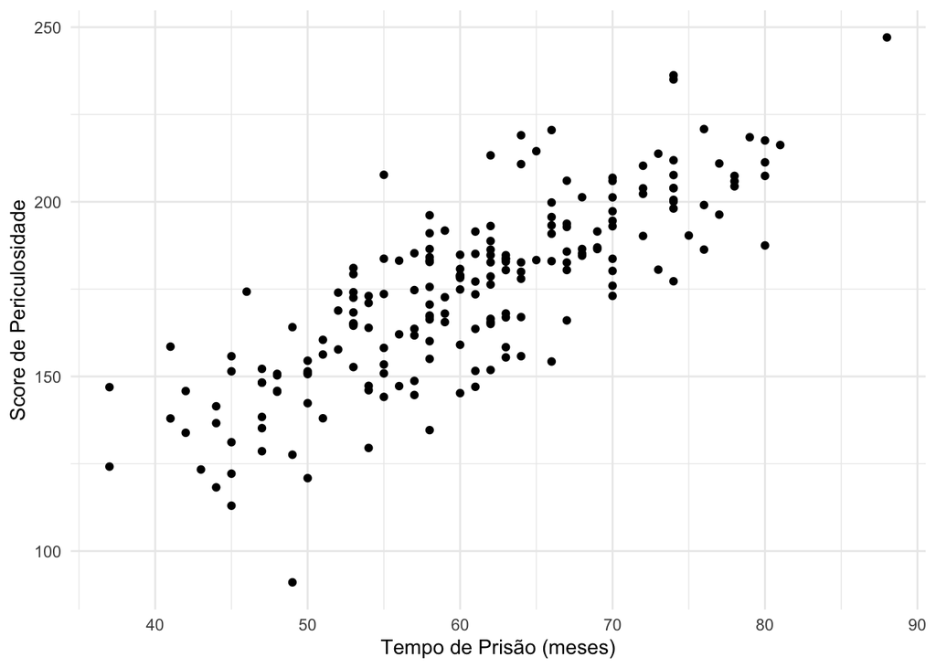

```r
ggplot(data = dados,
       mapping = aes(x = tempo_preso,
                     y = score_periculosidade)) +
  geom_point() +
  labs(y = "Score de Periculosidade", x = "Tempo de Prisão (meses)") +
  theme_minimal()
```

### 7.2. Estimativa pontual do coeficiente de correlação (r)

```r
r_amostral <- cor(x = dados$tempo_preso,
                  y = dados$score_periculosidade,
                  use = "pairwise.complete.obs")
print(r_amostral)
```

```
## [1] 0.8037558
```

### 7.3. Teste de Correlação de Pearson (bilateral)

```r
cor.test(x = dados$tempo_preso,
         y = dados$score_periculosidade,
         method = "pearson",
         alternative = "two.sided",
         conf.level = 0.95)
```

```
##
##  Pearson's product-moment correlation
##
## data:  dados$tempo_preso and dados$score_periculosidade
## t = 19.009, df = 198, p-value < 2.2e-16
## alternative hypothesis: true correlation is not equal to 0
## 95 percent confidence interval:
##  0.7484808 0.8479398
## sample estimates:
##       cor
## 0.8037558
```

## 8. Conclusão da Questão 3

O valor do coeficiente de correlação de Pearson é de aproximadamente 0.804. O teste de hipóteses ($H_0$ : P=0) foi rejeitado, pois o p-valor (<2.2e-16) foi inferior ao nível de significância adotado ($\alpha$=0.05). A correlação é forte e positiva, indicando que um tempo de prisão mais longo está significativamente associado a um score de periculosidade mais elevado. Portanto,

> **Resposta:** Sim, existe correlação estatisticamente entre tempo de prisão e o score de periculosidade.

# Questão 4:

Há relação entre o sexo e a reincidência dos indivíduos? Utilize um nível de significância de 5% e apresente o teste estatístico utilizado.

## 1. Análise Exploratória dos dados relativos a sexo e reincidência

Inicialmente, criaremos uma tabela de contingência contendo os dados relevantes (no caso, sexo e reincidência).

```r
conting <- table(dados$sexo, dados$reincidente)
cat('\nTabela de contingência (sexo x reincidência):\n')
```

```
##
## Tabela de contingência (sexo x reincidência):
```

```r
print(knitr::kable(conting))
```

```
##
##
## |          | Não| Sim|
## |:---------|---:|---:|
## |Masculino |  49|  13|
## |Feminino  | 113|  25|
```

```r
prop_por_sexo <- prop.table(conting, margin = 1) # linhas somam 1
cat('\nProporção de reincidência por sexo (linhas = sexo):\n')
```

```
##
## Proporção de reincidência por sexo (linhas = sexo):
```

```r
print(round(prop_por_sexo, 3))
```

```
##
##               Não   Sim
##   Masculino 0.790 0.210
##   Feminino  0.819 0.181
```

## 2. Análise de proporcionalidade

Faremos a análise a partir de dois gráficos: barras empilhadas e barras lado a lado.

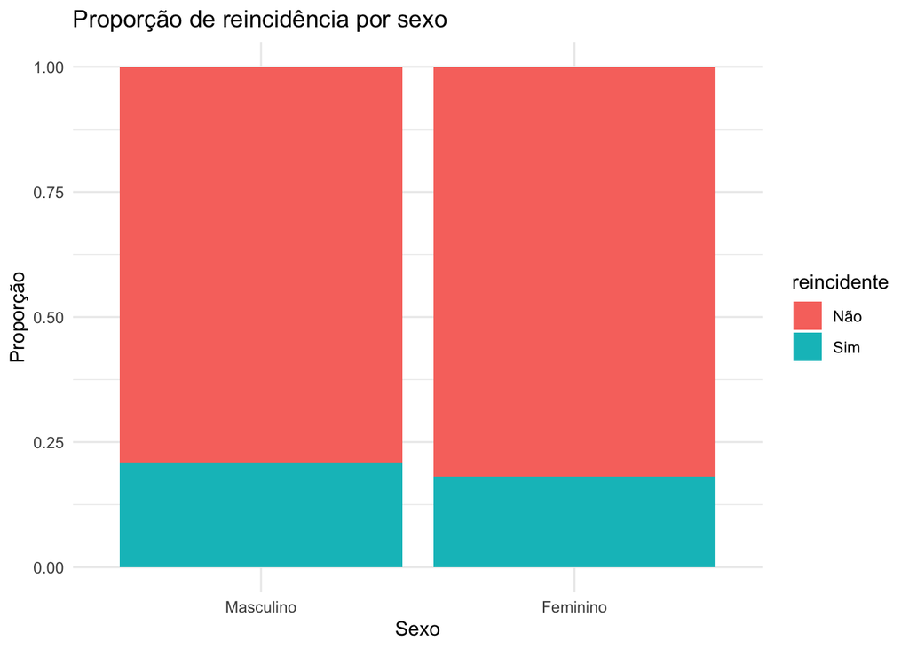

```r
plot_df <- dados %>% dplyr::count(sexo, reincidente) %>% dplyr::group_by(sexo) %>% dplyr::mutate(prop = n / sum(n))

p <- ggplot(plot_df, aes(x = sexo, y = prop, fill = reincidente)) +
  geom_col(position = 'stack') +
  labs(title = 'Proporção de reincidência por sexo', y = 'Proporção', x = 'Sexo') +
  theme_minimal()

print(p)
```

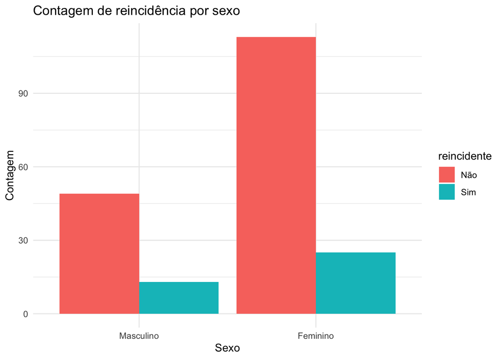

```r
p2 <- ggplot(plot_df, aes(x = sexo, y = n, fill = reincidente)) +
  geom_col(position = 'dodge') +
  labs(title = 'Contagem de reincidência por sexo', y = 'Contagem', x = 'Sexo') +
  theme_minimal()
print(p2)
```

## 3. Escolher e aplicar teste estatístico

Para a escolha e aplicação do teste estatístico, pode-se utilizar a seguinte regra prática: se tabela 2x2 e todas as frequências esperadas >= 5, utiliza-se o teste Qui-quadrado de Pearson; entretanto, se alguma frequência esperada for < 5, pode ser feito o teste Fisher exato.

```r
if(all(dim(conting) == c(2,2))) {
  # calcular teste qui-quadrado com correção de Yates
  chisq_res <- suppressWarnings(chisq.test(conting, correct = TRUE))
  expected <- chisq_res$expected
  cat('\nFrequências esperadas (Qui-quadrado):\n')
  print(round(expected, 2))
  min_expected <- min(expected)
  cat('\nMenor frequência esperada =', round(min_expected, 3), '\n')


  if(min_expected < 5) {
    cat('\nAlguma célula com valor esperado < 5 -> Aplicando Fisher Exact Test (mais apropriado para contagens pequenas)\n')
    fisher_res <- fisher.test(conting)
    print(fisher_res)
    pval <- fisher_res$p.value
    est_or <- if(!is.null(fisher_res$estimate)) fisher_res$estimate else NA
    confint_or <- if(!is.null(fisher_res$conf.int)) fisher_res$conf.int else NA
    test_used <- 'Fisher Exact Test'
  } else {
    cat('\nTodas as células com valor esperado >= 5 -> Aplicando Qui-quadrado de Pearson\n')
    print(chisq_res)
    pval <- chisq_res$p.value
    est_or <- NA
    confint_or <- NA
    test_used <- 'Chi-squared test (Pearson)'
  }
} else {
  chisq_res <- suppressWarnings(chisq.test(conting))
  expected <- chisq_res$expected
  cat('\nTabela não 2x2. Aplicando Qui-quadrado (sem correção de Yates).\n')
  print(chisq_res)
  pval <- chisq_res$p.value
  test_used <- 'Chi-squared test (Pearson) - tabela RxC'
  est_or <- NA
  confint_or <- NA
}
```

```
##
## Frequências esperadas (Qui-quadrado):
##
##                Não   Sim
##   Masculino  50.22 11.78
##   Feminino  111.78 26.22
##
## Menor frequência esperada = 11.78
##
## Todas as células com valor esperado >= 5 -> Aplicando Qui-quadrado de Pearson
##
##  Pearson's Chi-squared test with Yates' continuity correction
##
## data:  conting
## X-squared = 0.078738, df = 1, p-value = 0.779
```

## 4. Interpretação final com nível de significância alpha = 0.05

Por fim, passaremos à interpretação final da existência ou não de correlação, criando um *loop if-else* para rejeitar ou não a hipótese nula.

```r
alpha <- 0.05
cat('\n\n--- RESULTADO ---\n')
```

```
##
##
## --- RESULTADO ---
```

```r
cat('Teste utilizado:', test_used, '\n')
```

```
## Teste utilizado: Chi-squared test (Pearson)
```

```r
cat('p-valor =', format.pval(pval, digits = 4), '\n')
```

```
## p-valor = 0.779
```

```r
if(pval < alpha) {
  cat('Conclusão: rejeita-se $H_0$ ao nível de', alpha*100, '% -> existe evidência
  estatística de associação entre sexo e reincidência.\n')
} else {
  cat('Conclusão: Não se rejeita $H_0$ ao nível de', alpha*100, '% -> não há evidência
  estatística suficiente de associação entre sexo e reincidência.\n')
}
```

```
## Conclusão: Não se rejeita $H_0$ ao nível de 5 % -> não há evidência
##   estatística suficiente de associação entre sexo e reincidência.
```

## 5. Resposta final da questão 4

> **Resposta:** Não há evidência suficiente de correlação entre sexo e reincidência.

# Questão 5:

Ajuste um modelo de regressão para o score de periculosidade, considerando todas as variáveis explicativas disponíveis. Avalie as suposições de normalidade e homoscedasticidade dos resíduos e interprete os coeficientes estimados. Qual o percentual de explicação do modelo? Utilize um nível de significância de 5%.

## 1. Análise Exploratória Preliminar

### 1.1. Estatísticas Descritivas

```r
# Estatísticas da variável resposta
stats_score <- data.frame(
  Estatística = c("Média", "Desvio Padrão", "Mínimo", "Máximo", "Mediana"),
  Valor = c(
    mean(dados$score_periculosidade, na.rm = TRUE),
    sd(dados$score_periculosidade, na.rm = TRUE),
    min(dados$score_periculosidade, na.rm = TRUE),
    max(dados$score_periculosidade, na.rm = TRUE),
    median(dados$score_periculosidade, na.rm = TRUE)
  )
)

kable(stats_score, digits = 2,
      caption = "Estatísticas Descritivas do Score de Periculosidade",
      col.names = c("Estatística", "Valor")) |>
  kable_styling(bootstrap_options = c("striped", "hover"),
                full_width = FALSE)
```

Estatísticas Descritivas do Score de Periculosidade

| Estatística | Valor |
| --- | --- |
| Média | 174.52 |
| Desvio Padrão | 25.70 |
| Mínimo | 91.05 |
| Máximo | 247.07 |
| Mediana | 177.21 |

### 1.2. Correlações entre Variáveis Numéricas

```r
# Matriz de correlação
cor_matrix <- cor(dados[, c("idade", "tempo_preso", "score_periculosidade")],
                  use = "complete.obs")

kable(cor_matrix, digits = 3,
      caption = "Matriz de Correlação entre Variáveis Numéricas") |>
  kable_styling(bootstrap_options = c("striped", "hover"),
                full_width = FALSE)
```

Matriz de Correlação entre Variáveis Numéricas

|  | idade | tempo_preso | score_periculosidade |
| --- | --- | --- | --- |
| idade | 1.000 | -0.016 | -0.002 |
| tempo_preso | -0.016 | 1.000 | 0.804 |
| score_periculosidade | -0.002 | 0.804 | 1.000 |

**Observações**:

- A correlação entre idade e score de periculosidade é de **-0.002**
- A correlação entre tempo de prisão e score é de **0.804**

### 1.3. Visualizações Exploratórias

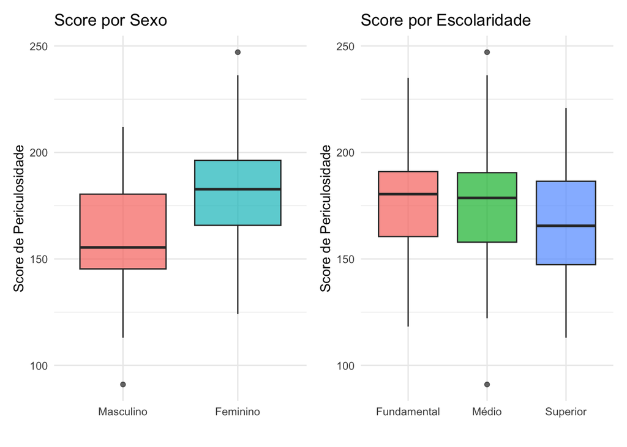

Distribuição do Score por Variáveis Categóricas

```r
p1 <- ggplot(dados, aes(x = sexo, y = score_periculosidade, fill = sexo)) +
  geom_boxplot(alpha = 0.7) +
  labs(title = "Score por Sexo", x = "", y = "Score de Periculosidade") +
  theme_minimal() +
  theme(legend.position = "none")

p2 <- ggplot(dados, aes(x = escolaridade, y = score_periculosidade, fill = escolaridade)) +
  geom_boxplot(alpha = 0.7) +
  labs(title = "Score por Escolaridade", x = "", y = "Score de Periculosidade") +
  theme_minimal() +
  theme(legend.position = "none")

p1 + p2
```

## 2. Ajuste e Interpretação do Modelo

### 2.1. Hipóteses

**Para cada coeficiente $\beta_i$**:

- **$H_0$**: $\beta_i$ = 0 (a variável não tem efeito sobre o score)
- **$H_1$**: $\beta_i$ $\neq$ 0 (a variável tem efeito sobre o score)

**Para o modelo completo (Teste F)**:

- **$H_0$**: $\beta_1$ = $\beta_2$ = … = $\beta_k$ = 0 (nenhuma variável tem efeito)
- **$H_1$**: Pelo menos um $\beta_i$ $\neq$ 0

**Nível de significância**: $\alpha$ = 0,05 Ajustamos um Modelo de Regressão Linear Múltipla com a variável resposta score_periculosidade e todas as demais variáveis como preditoras.

```r
modelo_completo <- lm(score_periculosidade ~ ., data = dados)
summary(modelo_completo)
```

```
##
## Call:
## lm(formula = score_periculosidade ~ ., data = dados)
##
## Residuals:
##     Min      1Q  Median      3Q     Max
## -40.670  -6.165  -0.523   7.194  26.372
##
## Coefficients:
##                       Estimate Std. Error t value Pr(>|t|)
## (Intercept)           38.83585    5.17956   7.498 2.37e-12 ***
## idade                  0.01420    0.03827   0.371  0.71102
## escolaridadeMédio     -6.30686    1.69444  -3.722  0.00026 ***
## escolaridadeSuperior -11.26859    1.96863  -5.724 3.97e-08 ***
## reincidenteSim        15.81332    1.89404   8.349 1.37e-14 ***
## filhosSim             -1.04281    1.49647  -0.697  0.48675
## sexoFeminino          19.12308    1.60456  11.918  < 2e-16 ***
## tempo_preso            2.02675    0.07502  27.015  < 2e-16 ***
## casadoSim              2.44650    1.54078   1.588  0.11398
## ---
## Signif. codes:  0 '***' 0.001 '**' 0.01 '*' 0.05 '.' 0.1 ' ' 1
##
## Residual standard error: 10.42 on 191 degrees of freedom
## Multiple R-squared:  0.8421, Adjusted R-squared:  0.8355
## F-statistic: 127.3 on 8 and 191 DF,  p-value: < 2.2e-16
```

Percentual de Explicação do Modelo ($R^2$ Ajustado): O R-squared ajustado é a métrica mais adequada para múltiplos preditores, pois penaliza a inclusão de variáveis não-significativas.  
Os coeficientes ($\beta$) representam a mudança média no score_periculosidade para um aumento de uma unidade na variável preditora, mantendo todas as outras variáveis constantes.  
Intercepto: O valor do Intercepto ($\beta_0$) indica o score esperado quando todas as variáveis quantitativas são zero e todas as variáveis categóricas estão no nível de referência (base).

Opcionalmente, pode-se realizar o Teste de Multicolinearidade (VIF).

```r
vif(modelo_completo)
```

```
##                  GVIF Df GVIF^(1/(2*Df))
## idade        1.003271  1        1.001634
## escolaridade 1.032573  2        1.008046
## reincidente  1.016037  1        1.007987
## filhos       1.028664  1        1.014231
## sexo         1.013473  1        1.006714
## tempo_preso  1.021259  1        1.010574
## casado       1.018384  1        1.009150
```

## 3. Avaliação dos Pressupostos

A validade das inferências do modelo de regressão depende da satisfação dos pressupostos sobre os resíduos.

### 3.1. Normalidade dos Resíduos

A suposição é que os resíduos sigam uma distribuição normal. Para verificar essa suposição, podemos visualizar o QQ-Plot dos resíduos.

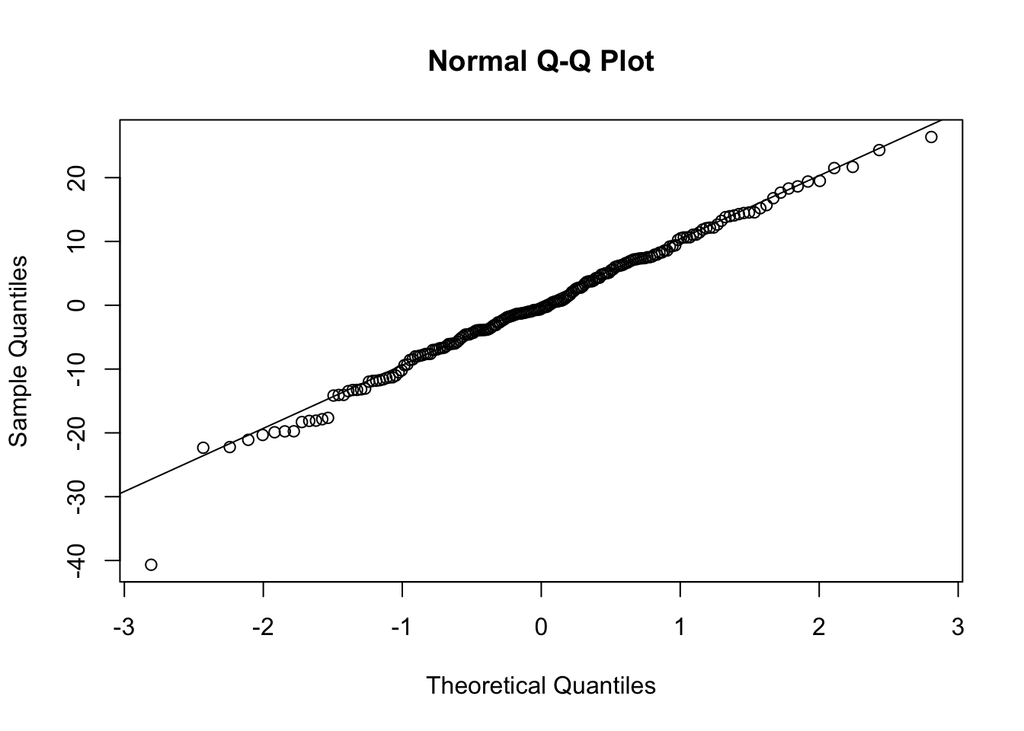

```r
qqnorm(modelo_completo$residuals)
qqline(modelo_completo$residuals)
```

Em seguida, realizamos o teste Formal de Shapiro-Wilk (H0: Normalidade).

```r
shapiro.test(modelo_completo$residuals)
```

```
##
##  Shapiro-Wilk normality test
##
## data:  modelo_completo$residuals
## W = 0.99074, p-value = 0.2289
```

### 3.2. Homocedasticidade dos Resíduos

A suposição é que a variância dos resíduos seja constante, independente do valor predito. Vamos verificar o Gráfico de Resíduos vs. Valores Ajustados.

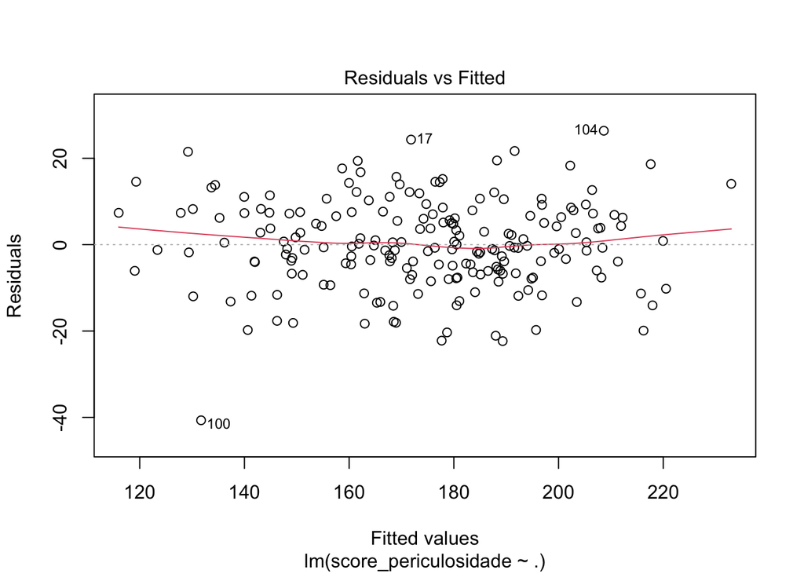

```r
plot(modelo_completo, which = 1)
```

Em seguida, faremos o Teste Formal de Breusch-Pagan (H0: Homocedasticidade).

```r
ols_test_breusch_pagan(modelo_completo)
```

```
##
##  Breusch Pagan Test for Heteroskedasticity
##  -----------------------------------------
##  Ho: the variance is constant
##  Ha: the variance is not constant
##
##                       Data
##  ------------------------------------------------
##  Response : score_periculosidade
##  Variables: fitted values of score_periculosidade
##
##         Test Summary
##  ----------------------------
##  DF            =    1
##  Chi2          =    1.233215
##  Prob > Chi2   =    0.2667827
```

## 4. Conclusão Final do Modelo de Regressão Múltipla

O modelo de regressão múltipla, ajustado para predizer o **score_periculosidade**, apresentou o seguinte desempenho:

**Significância Global do Modelo**

> O p-valor do **Teste F** foi **$< 2.2e-16$**.  
> Como esse valor é **menor que 0.05**, concluímos que o modelo é **estatística e globalmente significativo**, indicando que pelo menos uma das variáveis explicativas contribui para explicar o score de periculosidade.

**Avaliação dos Pressupostos**

**Variáveis Significativas**

# Questão 6:

Realize um processo de seleção de variáveis a partir do modelo ajustado no item anterior. Para o novo modelo, repita as checagens dos pressupostos e a interpretação dos resultados.

## 1. Metodologia de Seleção

**Método utilizado**: Seleção Stepwise (ambas direções) baseada no critério AIC (Akaike Information Criterion)

O critério AIC busca o modelo que minimiza: AIC = -2log(L) + 2k, onde L é a verossimilhança e k é o número de parâmetros.

```r
modelo_reduzido <- step(modelo_completo, direction = "both", trace = 0)
```

## 2. Modelo Reduzido Selecionado

### 2.1 Fórmula do Modelo

```r
formula_reduzida <- formula(modelo_reduzido)
cat("**Modelo Reduzido**:\n\n")
```

**Modelo Reduzido**:

```r
cat(paste0("`", deparse(formula_reduzida), "`\n\n"))
```

`score_periculosidade ~ escolaridade + reincidente + sexo + tempo_preso +`

`casado`

```r
# Identificar variáveis incluídas e removidas
vars_completo <- all.vars(formula(modelo_completo))[-1]
vars_reduzido <- all.vars(formula(modelo_reduzido))[-1]
vars_removidas <- setdiff(vars_completo, vars_reduzido)

cat("**Variáveis mantidas**: ", paste(vars_reduzido, collapse = ", "), "\n\n")
```

**Variáveis mantidas**: escolaridade, reincidente, sexo, tempo_preso, casado

```r
if(length(vars_removidas) > 0) {
  cat("**Variáveis removidas**: ", paste(vars_removidas, collapse = ", "), "\n\n")
}
```

**Variáveis removidas**: idade, filhos

## 3. Comparação entre Modelos

```r
comparacao <- data.frame(
  Modelo = c("Completo", "Reduzido"),
  R2 = c(summary(modelo_completo)$r.squared,
         summary(modelo_reduzido)$r.squared),
  R2_Ajustado = c(summary(modelo_completo)$adj.r.squared,
                  summary(modelo_reduzido)$adj.r.squared),
  AIC = c(AIC(modelo_completo), AIC(modelo_reduzido)),
  BIC = c(BIC(modelo_completo), BIC(modelo_reduzido)),
  N_Variaveis = c(length(vars_completo), length(vars_reduzido))
)

comparacao$R2 <- sprintf("%.4f (%.2f%%)", comparacao$R2, comparacao$R2 * 100)
comparacao$R2_Ajustado <- sprintf("%.4f (%.2f%%)", comparacao$R2_Ajustado,
                                   as.numeric(sub(".*\\((.*)%\\)", "\\1", comparacao$R2_Ajustado)))
comparacao$AIC <- round(as.numeric(comparacao$AIC), 2)
comparacao$BIC <- round(as.numeric(comparacao$BIC), 2)

kable(comparacao,
      caption = "Comparação entre Modelo Completo e Modelo Reduzido",
      col.names = c("Modelo", "R²", "R² Ajustado", "AIC", "BIC", "Nº Variáveis")) |>
  kable_styling(bootstrap_options = c("striped", "hover"),
                full_width = FALSE)
```

Comparação entre Modelo Completo e Modelo Reduzido

[output not shown]

**Análise**:

- O modelo reduzido possui AIC menor que o modelo completo (diferença de 3.37 pontos).
- O R² ajustado manteve-se similar ou melhorou.

## 4. Resultados do Modelo Reduzido

### 4.1 Coeficientes Estimados

```r
coef_summary_red <- summary(modelo_reduzido)$coefficients
coef_df_red <- as.data.frame(coef_summary_red)
coef_df_red$Variavel <- rownames(coef_df_red)
coef_df_red <- coef_df_red[, c("Variavel", "Estimate", "Std. Error", "t value", "Pr(>|t|)")]
colnames(coef_df_red) <- c("Variável", "Coeficiente", "Erro Padrão", "t-value", "p-valor")

coef_df_red$Significância <- ifelse(coef_df_red$`p-valor` < 0.001, "***",
                                    ifelse(coef_df_red$`p-valor` < 0.01, "**",
                                           ifelse(coef_df_red$`p-valor` < 0.05, "*", "")))

kable(coef_df_red, digits = 4, row.names = FALSE,
      caption = "Coeficientes do Modelo Reduzido") |>
  kable_styling(bootstrap_options = c("striped", "hover"),
                full_width = FALSE) |>
  footnote(general = "*** p < 0.001; ** p < 0.01; * p < 0.05")
```

Coeficientes do Modelo Reduzido

| Variável | Coeficiente | Erro Padrão | t-value | p-valor | Significância |
| --- | --- | --- | --- | --- | --- |
| (Intercept) | 38.8247 | 4.6595 | 8.3324 | 0.0000 | *** |
| escolaridadeMédio | -6.4097 | 1.6801 | -3.8151 | 0.0002 | *** |
| escolaridadeSuperior | -11.2358 | 1.9601 | -5.7322 | 0.0000 | *** |
| reincidenteSim | 15.7629 | 1.8848 | 8.3630 | 0.0000 | *** |
| sexoFeminino | 19.1864 | 1.5964 | 12.0184 | 0.0000 | *** |
| tempo_preso | 2.0302 | 0.0745 | 27.2410 | 0.0000 | *** |
| casadoSim | 2.3756 | 1.5315 | 1.5512 | 0.1225 |  |

Note:  
*** p < 0.001; ** p < 0.01; * p < 0.05